# Intail Building Blocks

### Problem 1

Do simple math with numbers, addition, subtraction, multiplication, division

```r
1+1
```

```
## [1] 2
```

```r
3-2
```

```
## [1] 1
```

```r
4*6
```

```
## [1] 24
```

```r
5/7
```

```
## [1] 0.7142857
```

# Problem 2

Put numbers into variables, do simple math on the variables

```r
Norie <-1
ABC <-537848756781637

a <-1
b <-"five"

a+b
```

[output not shown]

# Problem 3

Write code that will place the numbers 1 to 100 separately into a variable using for loop. Then, again using the seq function.

```r
Numbers_List <-seq(1:100)

for (i in 1:length(Numbers_List)){
  print(Numbers_List[[i]])
}
```

```
## [1] 1
## [1] 2
## [1] 3
## [1] 4
## [1] 5
## [1] 6
## [1] 7
## [1] 8
## [1] 9
## [1] 10
## [1] 11
## [1] 12
## [1] 13
## [1] 14
## [1] 15
```

[output cut: 85 more lines]

# Problem 4

Find the sum of all the integer numbers from 1 to 100

```r
Numbers_List <-seq(1:100)

for (i in 1:length(Numbers_List)){
  print(Numbers_List[[i]])
}
```

```
## [1] 1
## [1] 2
## [1] 3
## [1] 4
## [1] 5
## [1] 6
## [1] 7
## [1] 8
## [1] 9
## [1] 10
## [1] 11
## [1] 12
## [1] 13
## [1] 14
## [1] 15
```

[output cut: 85 more lines]

```r
sum(Numbers_List)
```

```
## [1] 5050
```

# Problem 5

Write a function to find the sum of all integers between any two values.

# Problem 6

List all of the odd numbers from 1 to 100.

```r
Odd_numbers <-seq(1, 99, 2)
 print(Odd_numbers)
```

```
##  [1]  1  3  5  7  9 11 13 15 17 19 21 23 25 27 29 31 33 35 37 39 41 43 45
## [24] 47 49 51 53 55 57 59 61 63 65 67 69 71 73 75 77 79 81 83 85 87 89 91
## [47] 93 95 97 99
```

# Problem 7

```r
Prime_Numbers <-(1:500)*2
print(Prime_Numbers)
```

```
##   [1]    2    4    6    8   10   12   14   16   18   20   22   24   26   28
##  [15]   30   32   34   36   38   40   42   44   46   48   50   52   54   56
##  [29]   58   60   62   64   66   68   70   72   74   76   78   80   82   84
##  [43]   86   88   90   92   94   96   98  100  102  104  106  108  110  112
##  [57]  114  116  118  120  122  124  126  128  130  132  134  136  138  140
##  [71]  142  144  146  148  150  152  154  156  158  160  162  164  166  168
##  [85]  170  172  174  176  178  180  182  184  186  188  190  192  194  196
##  [99]  198  200  202  204  206  208  210  212  214  216  218  220  222  224
## [113]  226  228  230  232  234  236  238  240  242  244  246  248  250  252
## [127]  254  256  258  260  262  264  266  268  270  272  274  276  278  280
## [141]  282  284  286  288  290  292  294  296  298  300  302  304  306  308
## [155]  310  312  314  316  318  320  322  324  326  328  330  332  334  336
## [169]  338  340  342  344  346  348  350  352  354  356  358  360  362  364
## [183]  366  368  370  372  374  376  378  380  382  384  386  388  390  392
## [197]  394  396  398  400  402  404  406  408  410  412  414  416  418  420
```

[output cut: 21 more lines]

# Problem 8

Generate 100 random numbers

```r
rnorm(100)
```

```
##   [1]  0.877761486 -0.802378934  0.180688256  0.259576609 -0.746363679
##   [6]  0.491263808  1.141907675  0.462241988 -2.111798841  0.942156144
##  [11]  0.113194872 -1.222422706 -0.439434987  0.829230579  2.312923852
##  [16]  1.166344762 -2.575875697 -0.446638099 -0.530474302 -0.163081887
##  [21]  0.667579696 -0.002097955 -1.268410010  0.095089636  1.009429281
##  [26] -1.900446004  0.253945302  1.268517038  1.066238976  0.505207294
##  [31]  1.046763615  1.554871768  0.092151267 -0.195729320  0.970919141
##  [36] -0.345586949 -0.805317070 -0.841494249  0.882624505 -0.169377069
##  [41]  2.090930501 -0.465443156 -0.130359472  0.059659509  1.872897081
##  [46] -1.446722618  0.963406239 -0.759058422  0.631593588  0.116115235
##  [51] -0.677329137 -1.599038318  0.292771521 -0.224019820 -1.235043965
##  [56] -0.188800157 -0.418126843 -2.556520646 -0.327512238 -2.444056836
##  [61]  0.405076894 -0.257531456  0.030067917 -1.607900174 -1.733412717
##  [66] -0.869283801  0.340617088 -0.633734796 -0.175909154  1.298619604
##  [71]  0.278772851  0.738536686 -0.448543735  0.922334546  0.253569060
##  [76] -0.905947744 -0.444818738 -1.110962281 -0.055487338 -2.425697735
##  [81]  1.215871001  1.371003769 -0.869201343  0.207975741 -0.029166158
##  [86]  1.003672276  0.188695137 -0.159804694  0.117557347 -0.050832290
##  [91]  0.283939998  0.658698073 -0.955612816  1.567545352 -0.682916690
##  [96] -0.167286983  1.287525710 -0.265721213 -2.406732211  0.228075392
```

# Problem 9

Generate 100 random numbers within a specific range

```r
rnorm(100, mean = 6, sd = 6)
```

```
##   [1]  12.3611618   5.3664750  14.9449522   5.0495502   7.3776697
##   [6]  10.5716020  -2.5789768  10.2594467   9.1985679  -4.8826019
##  [11]  10.0524531   6.9389906  10.5230577   9.5758627   2.5985051
##  [16]   7.0598445  13.0517080   5.8908847   7.8099721  -6.1187615
##  [21]  11.4784204  11.7054006   4.1492036  16.5784243  12.5504222
##  [26]   8.4351718   6.3173053   7.9316718  13.6562440   2.8074765
##  [31]   7.8821709  12.7389722  -1.6406368  -2.9784647   0.9280771
##  [36]   4.9694766   3.3448020   5.5846696   4.2449848   2.6211724
##  [41]  -5.2670296 -12.8343113  12.0724152   9.3363796  -3.2110065
##  [46]   3.3023719   6.4317278   0.6339426  17.8086291   7.8703376
##  [51]   5.9247742  13.7429958  -2.8883012   8.2296689   9.6294900
##  [56]   5.3383312  10.0226385   4.3592539  -1.7206046   1.6509056
##  [61]  11.1170675   1.8279784  -9.1939351   8.5108810   0.8846037
##  [66]   4.9014410   1.5224031  11.0875915  15.1974931  -1.1830890
##  [71]  -0.9509108  -4.8788496  10.9159676   2.6263191   6.5362559
##  [76]   9.7462923  -1.2279125  -3.0293927  17.4596717   6.9674242
##  [81]   3.3294607  -2.0642026   0.7456690  -4.0330570   8.0383140
##  [86]  16.7562243  11.7971346   9.1864833  12.0274125  -3.8877516
##  [91]   0.7963952  15.7098582   8.6336949  -9.9310066   2.3395550
##  [96]   3.4845949  10.8528183  -4.1796040   1.8942201   4.3705948
```

# Problem 10 A Mean

Write your own functions to give descriptive statistics for a vector variable storing multiple numbers. Write functions for the following without using R intrinsics: mean, mode, median, range, standard deviation

```r
x_mean <-c(1,3,9,-22,22,6,7,10,15,4,25)
my_fun <-function(x_mean){ sum(x_mean)/length(x_mean)}
print(my_fun(x_mean))
```

```
## [1] 7.272727
```

# Problem B Mode

```r
Y<-c(1,3,9,-22,22,6,7,10,15,4,25,22,56,7,22,22)
table(Y)
```

```
## Y
## -22   1   3   4   6   7   9  10  15  22  25  56
##   1   1   1   1   1   2   1   1   1   4   1   1
```

```r
C=table(Y)

names(which.max(C))
```

```
## [1] "22"
```

# Problem 11

Count the number of characters in a string variable.

```r
Count1 <-c(1,3,9,-22,22,6,7,10,15,4,25)

length(Count1)
```

```
## [1] 11
```

# Problem 12

Count the number of words in a string variable

```r
letter<-c("jtymhrtyoilnk")
strsplit(letter, split = "")
```

```
## [[1]]
##  [1] "j" "t" "y" "m" "h" "r" "t" "y" "o" "i" "l" "n" "k"
```

```r
length(letter)
```

```
## [1] 1
```

# Problem 13

Count the number of sentences in a string variable

```r
strV<-"How can we understand R if we don't read"
sapply(strsplit(strV," "),length)
```

```
## [1] 9
```

# Problem 14 *ASK*

Count the number of times a specific character occurs in a string variable

```r
Str1<-"bbbjshjfsiiiisihfksbjsuuuus"
(strsplit(Str1,""))
```

```
## [[1]]
##  [1] "b" "b" "b" "j" "s" "h" "j" "f" "s" "i" "i" "i" "i" "s" "i" "h" "f"
## [18] "k" "s" "b" "j" "s" "u" "u" "u" "u" "s"
```

```r
table(Str1)
```

```
## Str1
## bbbjshjfsiiiisihfksbjsuuuus
##                           1
```

# Problem 15

Do a logical test to see if one word is found within the text of another string variable.

```r
Word<-"Learning"
sentence<-" Learning R is hard "

grepl(Word,sentence)
```

```
## [1] TRUE
```

# Problem 16 ASK

Put the current computer time in milliseconds into a variable

```r
print(as.numeric(Sys.time())*1000, digits=15)
```

```
## [1] 1556994579774.85
```

# Problem 17

# Problem 18

# Problem 19

Output the contents of a variable to a .txt file

# Problem 20

Create a variable that stores a 20x20 matrix of random numbers

# Problem 21

Output any matrix to a txt file using commas or tabs to separate column values, and new lines to separate row values

## 3.4 Harder Problems

# Question 1

```r
for (a in 1:100) {
 if (a %% 3 == 0) {print("Fizz")}
 else if (a %% 5 == 0) {print("Buzz")}
 else print(a)
}
```

```
## [1] 1
## [1] 2
## [1] "Fizz"
## [1] 4
## [1] "Buzz"
## [1] "Fizz"
## [1] 7
## [1] 8
## [1] "Fizz"
## [1] "Buzz"
## [1] 11
## [1] "Fizz"
## [1] 13
## [1] 14
## [1] "Fizz"
```

[output cut: 85 more lines]

# Question 2

Frequency Counts Take text as input, and be able to produce a table that shows the counts for each character in the text. This problem is related to the earlier easy problem asking you to count the number of times that a single letter appears in a text. The slightly harder problem is the more general version: count the frequencies of all unique characters in a text.

```r
a<-"some text that has some letters"
```

# Question 3 ask

Test the Random Number Generator Test the random number generator for a flat distribution. Generate a few million random numbers between 0 and 100. Count the number of 0s, 1s, 2s, 3s, etc. all the way up to 100. Look at the counts for each of the numbers and determine if they are relatively equal. For example, you could plot the counts in Excel to make a histogram. If all of the bars are close to being flat, then each number had an equal chance of being selected, and the random number generator is working without bias.

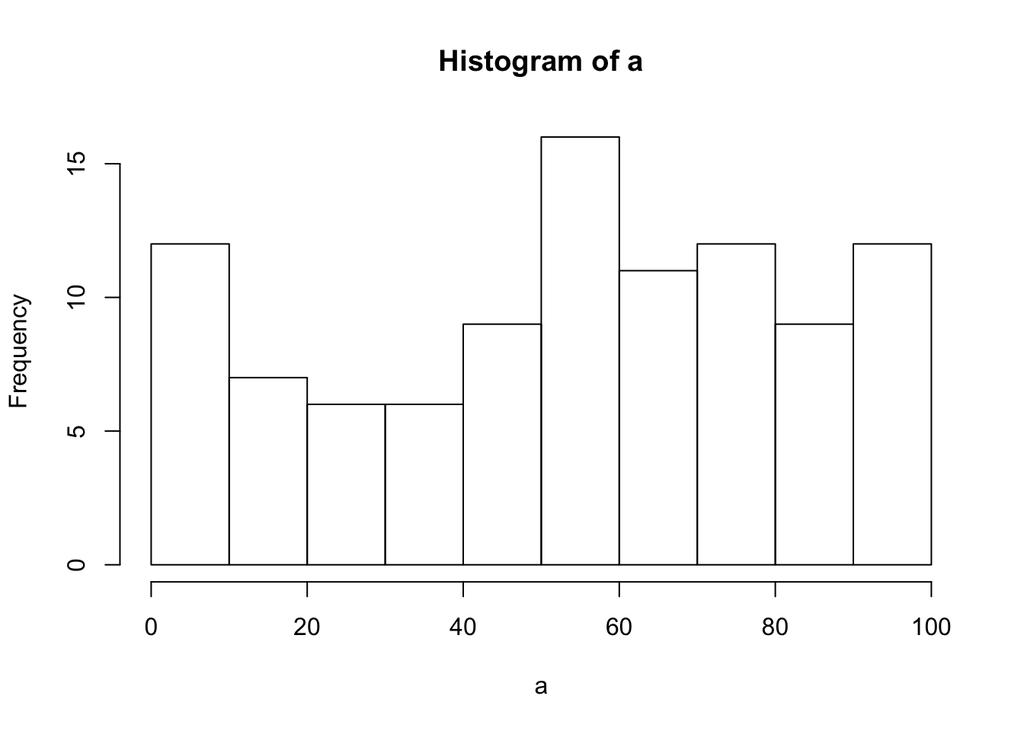

```r
a<-runif(100,0,100)
hist(a)
```

# Question 4

Create a multiplication table Generate a matrix for a multiplication table. For example, the labels for the columns could be the numbers 1 to 10, and the labels for the rows could be the numbers 1 to 10. The contents of each of the cells in the matrix should be correct answer for multiplying the column value by the row value.

```r
X<-c(1,2,3,4,5,6,7,8,9,10)
X*2
```

```
##  [1]  2  4  6  8 10 12 14 16 18 20
```

```r
for(i in 1:10) {
print(paste(X,'x', i, '=', X*i))
}
```

```
##  [1] "1 x 1 = 1"   "2 x 1 = 2"   "3 x 1 = 3"   "4 x 1 = 4"   "5 x 1 = 5"
##  [6] "6 x 1 = 6"   "7 x 1 = 7"   "8 x 1 = 8"   "9 x 1 = 9"   "10 x 1 = 10"
##  [1] "1 x 2 = 2"   "2 x 2 = 4"   "3 x 2 = 6"   "4 x 2 = 8"   "5 x 2 = 10"
##  [6] "6 x 2 = 12"  "7 x 2 = 14"  "8 x 2 = 16"  "9 x 2 = 18"  "10 x 2 = 20"
##  [1] "1 x 3 = 3"   "2 x 3 = 6"   "3 x 3 = 9"   "4 x 3 = 12"  "5 x 3 = 15"
##  [6] "6 x 3 = 18"  "7 x 3 = 21"  "8 x 3 = 24"  "9 x 3 = 27"  "10 x 3 = 30"
##  [1] "1 x 4 = 4"   "2 x 4 = 8"   "3 x 4 = 12"  "4 x 4 = 16"  "5 x 4 = 20"
##  [6] "6 x 4 = 24"  "7 x 4 = 28"  "8 x 4 = 32"  "9 x 4 = 36"  "10 x 4 = 40"
##  [1] "1 x 5 = 5"   "2 x 5 = 10"  "3 x 5 = 15"  "4 x 5 = 20"  "5 x 5 = 25"
##  [6] "6 x 5 = 30"  "7 x 5 = 35"  "8 x 5 = 40"  "9 x 5 = 45"  "10 x 5 = 50"
##  [1] "1 x 6 = 6"   "2 x 6 = 12"  "3 x 6 = 18"  "4 x 6 = 24"  "5 x 6 = 30"
##  [6] "6 x 6 = 36"  "7 x 6 = 42"  "8 x 6 = 48"  "9 x 6 = 54"  "10 x 6 = 60"
##  [1] "1 x 7 = 7"   "2 x 7 = 14"  "3 x 7 = 21"  "4 x 7 = 28"  "5 x 7 = 35"
##  [6] "6 x 7 = 42"  "7 x 7 = 49"  "8 x 7 = 56"  "9 x 7 = 63"  "10 x 7 = 70"
##  [1] "1 x 8 = 8"   "2 x 8 = 16"  "3 x 8 = 24"  "4 x 8 = 32"  "5 x 8 = 40"
##  [6] "6 x 8 = 48"  "7 x 8 = 56"  "8 x 8 = 64"  "9 x 8 = 72"  "10 x 8 = 80"
##  [1] "1 x 9 = 9"   "2 x 9 = 18"  "3 x 9 = 27"  "4 x 9 = 36"  "5 x 9 = 45"
##  [6] "6 x 9 = 54"  "7 x 9 = 63"  "8 x 9 = 72"  "9 x 9 = 81"  "10 x 9 = 90"
##  [1] "1 x 10 = 10"   "2 x 10 = 20"   "3 x 10 = 30"   "4 x 10 = 40"
##  [5] "5 x 10 = 50"   "6 x 10 = 60"   "7 x 10 = 70"   "8 x 10 = 80"
##  [9] "9 x 10 = 90"   "10 x 10 = 100"
```

# Question 5 *ask to explain*

Encrypt and Decrypt the Alphabet Turn any normal english text into an encrypted version of the text, and be able to turn any decrypted text back into normal english text. A simple encryption would be to scramble the alphabet such that each letter corresponds to a new randomly chosen (but unique) letter.

```r
old <- c("A B C D E F G H I J K L M N O P Q R S T U V W X Y Z ", "a b c d e f g h i j k l m n  o p q r s t u v w x y z", 0:9)

new <- sample(old)

old_string <- paste(old, collapse = "")
new_string <- paste(new, collapse = "")

encrypt <- function(message) {
  chartr(old_string, new_string, message)
}

decrypt <- function(message) {
  chartr(new_string, old_string, message)
}
```

# Question 6

```r
sample(c(1,2,3,4,5,6),2)
```

```
## [1] 4 3
```

```r
total_sum<-0
number_of_rolls<-0
while(total_sum < 25){
  number_of_rolls <- number_of_rolls+1
  total_sum <-total_sum+sample(c(1,2,3,4,5,6),1)
}
```

## Question 7

Dice-rolling simulations. Assume that a pair of dice are rolled. Using monte carlo-simulation, compute the probabilities of rolling a 2, 3, 4, 5, 6, 7, 8, 9, 10, 11, and 12, respectively.

```r
R2<-sample(sample(2:12,size = 100,replace = TRUE, prob = table(outer(1:6,1:6,"+")) / 36)
)
```

# Question 8

Monte Hall problem. The monte-hall problem is as follows. A contestant in a game show is presented with three closed doors. They are told that a prize is behind one door, and two goats are behind the other two doors. They are asked to choose which door contains the prize. After making their choice the game show host opens one of the remaining two doors (not chosen by the contestant), and reveals a goat. There are now two door remaining. The contestant is asked if they would like to switch their choice to the other door, or keep their initial choice. The correct answer is that the participant should switch their initial choice, and choose the other door. This will increase their odds of winning. Demonstrate by monte-carlo simulation that the odds of winning is higher if the participant switches than if the participants keeps their original choice.

# Question 9

100 doors problem. Problem: You have 100 doors in a row that are all initially closed. You make 100 passes by the doors. The first time through, you visit every door and toggle the door (if the door is closed, you open it; if it is open, you close it). The second time you only visit every 2nd door (door 2, 4, 6, etc.). The third time, every 3rd door (door 3, 6, 9, etc.), etc, until you only visit the 100th door.

# Question 10

Question: What state are the doors in after the last pass? Which are open, which are closed?

# Question 11

99 Bottles of Beer Problem In this puzzle, write code to print out the entire “99 bottles of beer on the wall”" song. For those who do not know the song, the lyrics follow this form: X bottles of beer on the wall X bottles of beer Take one down, pass it around X-1 bottles of beer on the wall

Where X and X-1 are replaced by numbers of course, from 99 all the way down to 0.

# Question 12

Random Tic-Tac-Toe Imagine that two players make completely random choices when playing tic-tac-toe. Each game will either end in a draw or one of the two players will win. Create a monte-carlo simulation of this “random” version of tic-tac-toe. Out 10,000 simulations, what proportion of the time is the game won versus drawn?

```r
#data framee has rows n columns similar to excel.
#data frame example
a<- data.frame()

df1 = data.frame(name = c("Norlander","Annalouise","Marsha","Angelina"),
                 Graduated_projected = c(2020,2020,2020,2020))
df2 = data.frame(Birth_place = c("Trinidad","U.S.A","Haiti","London"),
                 Birth_year = c(1990,1992,1995,1993))

cbind (df1, df2)
```

```
##         name Graduated_projected Birth_place Birth_year
## 1  Norlander                2020    Trinidad       1990
## 2 Annalouise                2020       U.S.A       1992
## 3     Marsha                2020       Haiti       1995
## 4   Angelina                2020      London       1993
```